# Praktikum 5 - Data Tidak Stasioner

Aida Darajati

2023-09-26

```r
library(ggplot2)
library(tsibble)
library(tseries)
library(MASS)
```

# Impor Data

```r
#install.packages("rio") #install jika belum ada
library(rio)
datashanghai <- import("https://raw.githubusercontent.com/aidara11/mpdw/main/Data/Data_Shanghai.csv")
head(datashanghai)
```

```
##         Date Average price
## 1 2002-01-01         14735
## 2 2002-02-01         14057
## 3 2002-03-01         14662
## 4 2002-04-01         16334
## 5 2002-05-01         18357
## 6 2002-06-01         20178
```

Ubah variabel Date menjadi index

```r
n = 204
index <- seq(1:n)

Average_price <- datashanghai$`Average price`

datalelang <- cbind(index,Average_price)
datalelang <- as.data.frame(datalelang)
datalelang
```

```
##     index Average_price
## 1       1         14735
## 2       2         14057
## 3       3         14662
## 4       4         16334
## 5       5         18357
## 6       6         20178
## 7       7         20904
## 8       8         21601
## 9       9         24040
## 10     10         27040
## 11     11         31721
## 12     12         27848
## 13     13         24267
## 14     14         25254
```

[output cut: 190 more lines]

Mengubah data agar terbaca sebagai data deret waktu

```r
datalelang.ts <- ts(datalelang$`Average_price`)
str(datalelang.ts)
```

```
##  Time-Series [1:204] from 1 to 204: 14735 14057 14662 16334 18357 20178 20904 21601 24040 27040 ...
```

## Stasioner dalam Rataan dan Ragam

### Plot *Time Series*

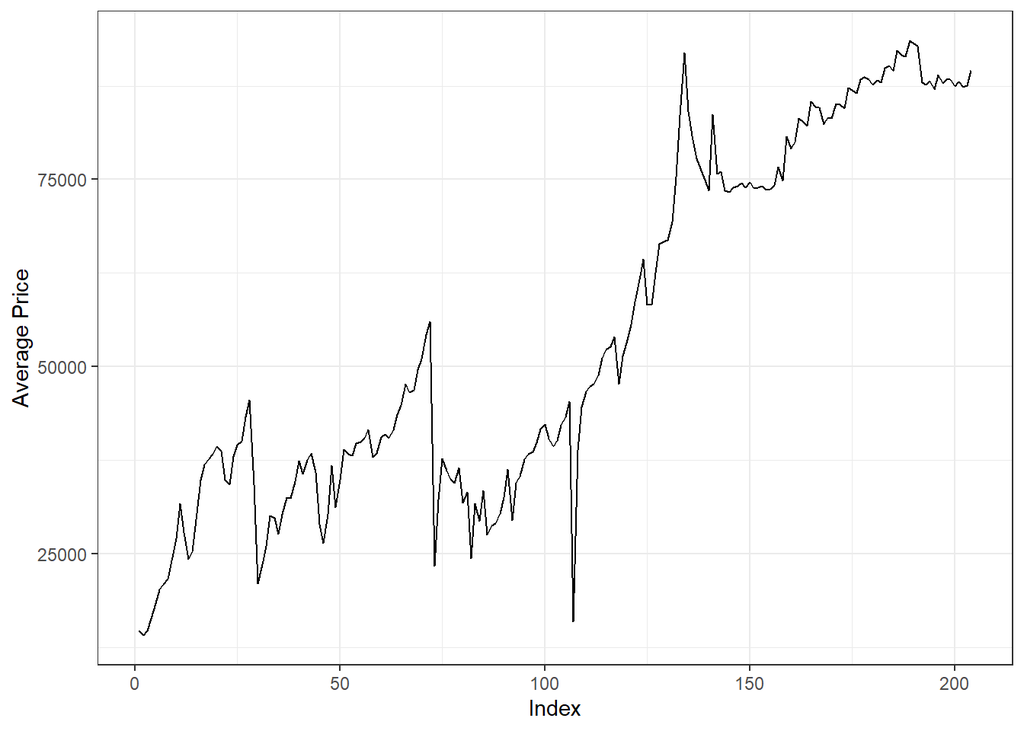

```r
plot_data <- datalelang.ts |> as_tsibble() |>
  ggplot(aes(x = datalelang$index, y = datalelang$Average_price)) + geom_line() + theme_bw() +
  xlab("Index") + ylab("Average Price")
plot_data
```

```r
mean(datalelang.ts)
```

```
## [1] 54358.04
```

Plot deret waktu di atas menunjukkan bahwa data tidak stasioner dalam rataan, ditandai dengan data yang tidak menyebar di sekitar nilai tengahnya. Selain itu, tidak stasioner dalam ragam, ditandai dengan lebar pita yang cenderung berbeda (tidak sama).

### Plot ACF

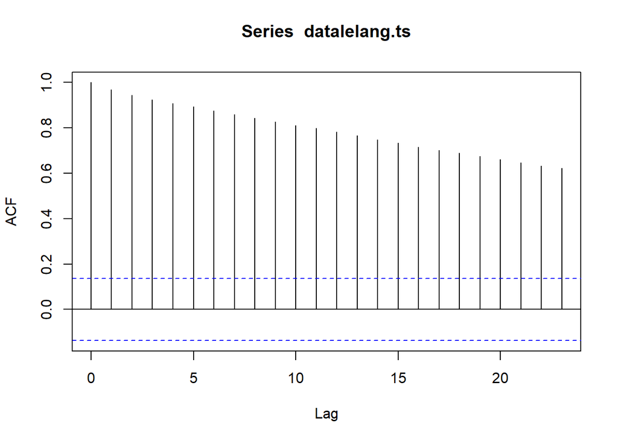

```r
acf(datalelang.ts)
```

Berdasarkan plot ACF, terlihat bahwa plot ACF pada data tersebut cenderung *tails off* dan tidak membentuk gelombang sinus. Akan tetapi, menurun secara perlahan sehingga data tidak stasioner.

### Uji ADF

```r
tseries::adf.test(datalelang.ts)
```

```
##
##  Augmented Dickey-Fuller Test
##
## data:  datalelang.ts
## Dickey-Fuller = -2.0642, Lag order = 5, p-value = 0.5492
## alternative hypothesis: stationary
```

$H_0$ : Data tidak stasioner dalam rataan

$H_1$ : Data stasioner dalam rataan

Berdasarkan uji ADF tersebut, didapat *p-value* sebesar 0.5492 yang lebih besar dari taraf nyata 5% sehingga tak tolak $H_0$ dan menandakan bahwa data tidak stasioner dalam rataan. Hal ini sesuai dengan hasil eksplorasi menggunakan plot time series dan plot ACF.

### Plot Box-Cox

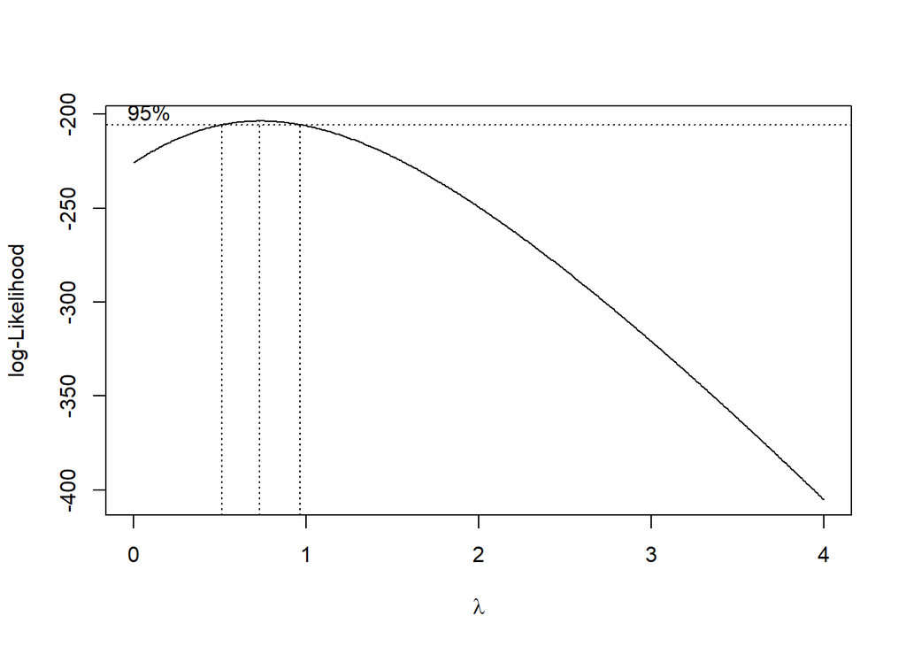

```r
n <- 204
index <- seq(1:n)
bc = boxcox(datalelang.ts~datalelang$index, lambda = seq(0,4,by=0.01))
```

```r
#Nilai Rounded Lambda
lambda <- bc$x[which.max(bc$y)]
lambda
```

```
## [1] 0.73
```

```r
#SK
bc$x[bc$y > max(bc$y) - 1/2 * qchisq(.95,1)]
```

```
##  [1] 0.52 0.53 0.54 0.55 0.56 0.57 0.58 0.59 0.60 0.61 0.62 0.63 0.64 0.65 0.66
## [16] 0.67 0.68 0.69 0.70 0.71 0.72 0.73 0.74 0.75 0.76 0.77 0.78 0.79 0.80 0.81
## [31] 0.82 0.83 0.84 0.85 0.86 0.87 0.88 0.89 0.90 0.91 0.92 0.93 0.94 0.95 0.96
```

Gambar di atas menunjukkan nilai *rounded value* ($\lambda$) optimum sebesar **0,73** dan pada selang kepercayaan 95% nilai memiliki batas bawah **0,52** dan batas atas **0,96**. Selang tersebut tidak memuat nilai satu sehingga dapat dikatakan bahwa data tidak stasioner dalam ragam.

### Partisi Data

#### Bagian 1

```r
dt_stas1 <- datalelang.ts[1:95] |> ts()
mean(dt_stas1)
```

```
## [1] 33950.09
```

```r
var(dt_stas1)
```

```
## [1] 70374644
```

#### Plot Time Series

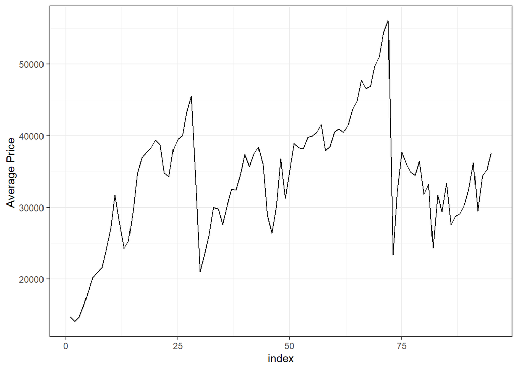

```r
dt_stas1 |> as_tsibble() |>
  ggplot(aes(x = index, y = value)) +
  geom_line() + theme_bw() +
  xlab("index") + ylab("Average Price ")
```

```r
mean(datalelang.ts)
```

```
## [1] 54358.04
```

#### Plot ACF

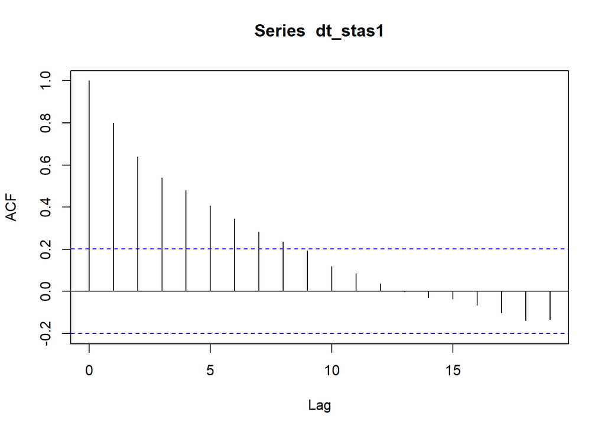

```r
acf(dt_stas1)
```

Berdasarkan plot ACF, terlihat bahwa plot ACF pada data tersebut cenderung *tails off* dan sedikit membentuk gelombang sinus.

#### Uji ADF

```r
tseries::adf.test(dt_stas1)
```

```
##
##  Augmented Dickey-Fuller Test
##
## data:  dt_stas1
## Dickey-Fuller = -2.7344, Lag order = 4, p-value = 0.2731
## alternative hypothesis: stationary
```

$H_0$ : Data tidak stasioner dalam rataan

$H_1$ : Data stasioner dalam rataan

Berdasarkan uji ADF tersebut, didapat *p-value* sebesar 0.2731 yang lebih besar dari taraf nyata 5% sehingga tak tolak $H_0$ dan menandakan bahwa data tidak stasioner dalam rataan. Hal ini sesuai dengan hasil eksplorasi menggunakan plot time series dan plot ACF.

#### Plot Boxcox

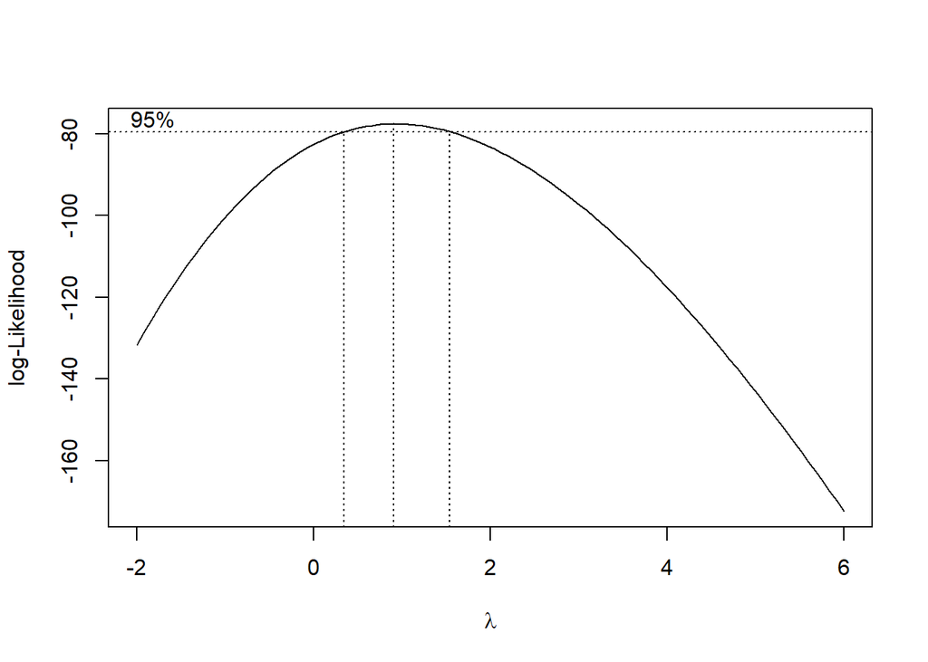

```r
index <- seq(1:95)
bc = boxcox(dt_stas1~index, lambda = seq(-2,6,by=1))
```

```r
#Nilai Rounded Lambda
lambda <- bc$x[which.max(bc$y)]
lambda
```

```
## [1] 0.9090909
```

```r
#SK
bc$x[bc$y > max(bc$y) - 1/2 * qchisq(.95,1)]
```

```
##  [1] 0.4242424 0.5050505 0.5858586 0.6666667 0.7474747 0.8282828 0.9090909
##  [8] 0.9898990 1.0707071 1.1515152 1.2323232 1.3131313 1.3939394 1.4747475
```

Gambar di atas menunjukkan nilai *rounded value* ($\lambda$) optimum sebesar **0.9090909** dan pada selang kepercayaan 95% nilai memiliki batas bawah **0.4242424** dan batas atas **1.4747475**. Selang tersebut memuat nilai satu sehingga dapat dikatakan bahwa data bangkitan stasioner dalam ragam.

#### Kesimpulan bagian 1

Data bangkitan tidak stasioner dalam rataan, namun stasioner dalam ragam.

#### Bagian 2

```r
dt_stas2 <- datalelang.ts[1:150] |> ts()
mean(dt_stas2)
```

```
## [1] 43263.42
```

```r
var(dt_stas2)
```

```
## [1] 290866680
```

#### Plot Time Series

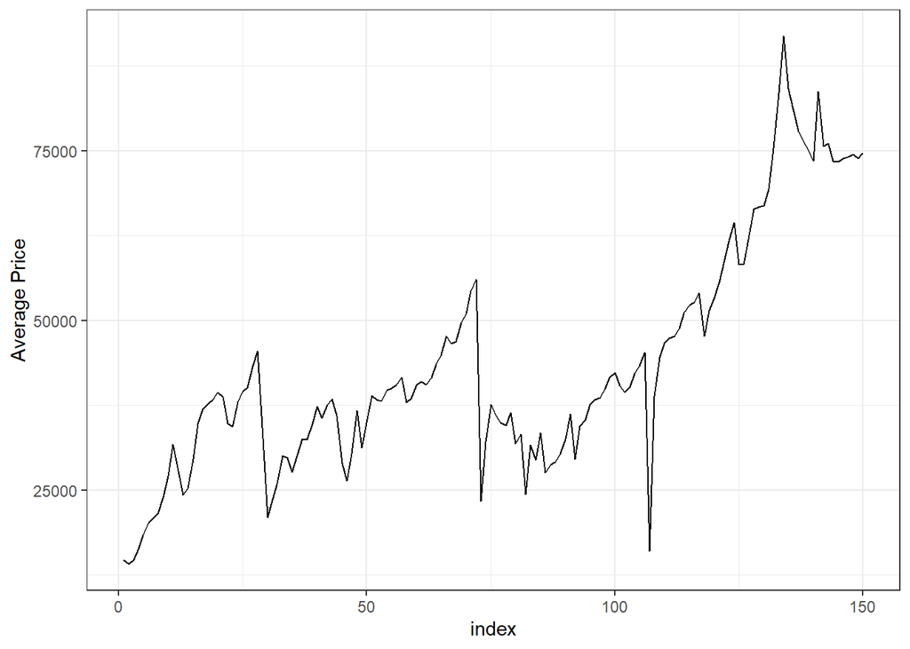

```r
dt_stas2 |> as_tsibble() |>
  ggplot(aes(x = index, y = value)) +
  geom_line() + theme_bw() +
  xlab("index") + ylab("Average Price")
```

```r
mean(datalelang.ts)
```

```
## [1] 54358.04
```

#### Plot ACF

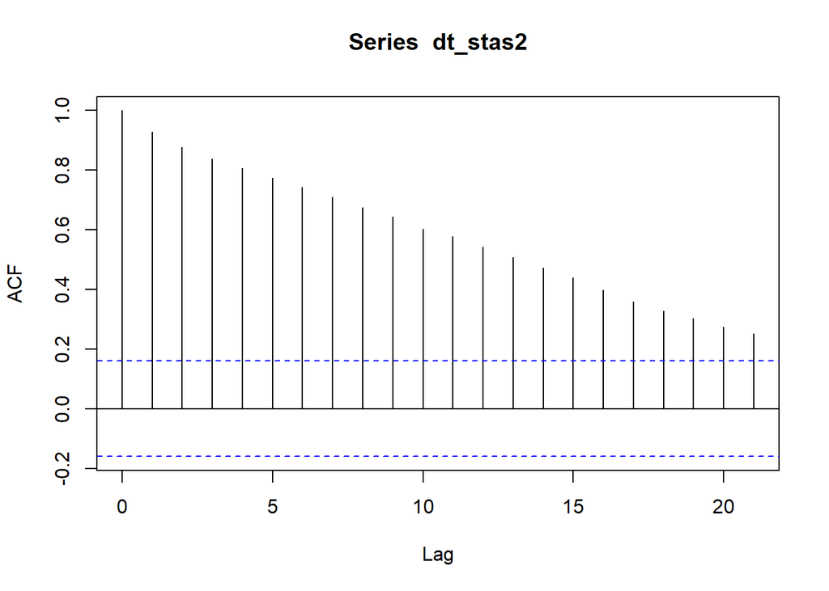

```r
acf(dt_stas2)
```

Berdasarkan plot ACF, terlihat bahwa plot ACF pada data tersebut cenderung *tails off* dan tidak membentuk gelombang sinus.

#### Uji ADF

```r
adf.test(dt_stas2)
```

```
##
##  Augmented Dickey-Fuller Test
##
## data:  dt_stas2
## Dickey-Fuller = -1.7566, Lag order = 5, p-value = 0.6778
## alternative hypothesis: stationary
```

$H_0$ : Data tidak stasioner dalam rataan

$H_1$ : Data stasioner dalam rataan

Berdasarkan uji ADF tersebut, didapat *p-value* sebesar 0.6778 yang lebih besar dari taraf nyata 5% sehingga tak tolak $H_0$ dan menandakan bahwa data tidak stasioner dalam rataan. Hal ini sesuai dengan hasil eksplorasi menggunakan plot time series dan plot ACF.

#### Plot Boxcox

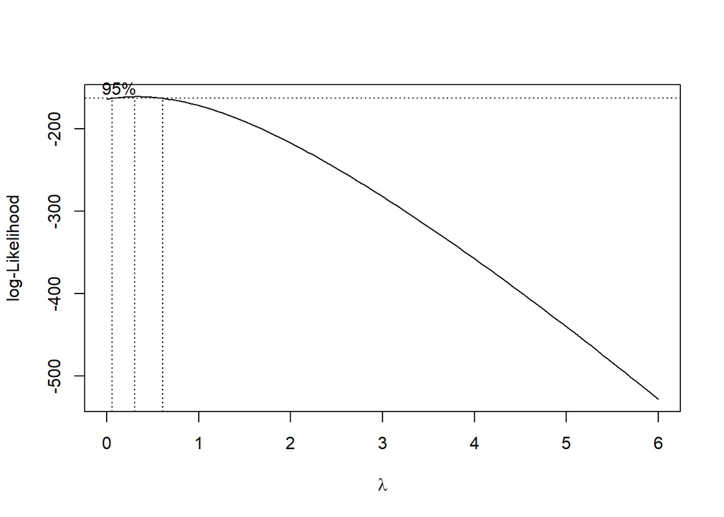

```r
index <- seq(1:150)
bc = boxcox(dt_stas2~index, lambda = seq(0,6,by=1))
```

```r
#Nilai Rounded Lambda
lambda <- bc$x[which.max(bc$y)]
lambda
```

```
## [1] 0.3030303
```

```r
#SK
bc$x[bc$y > max(bc$y) - 1/2 * qchisq(.95,1)]
```

```
##  [1] 0.06060606 0.12121212 0.18181818 0.24242424 0.30303030 0.36363636
##  [7] 0.42424242 0.48484848 0.54545455 0.60606061
```

Gambar di atas menunjukkan nilai *rounded value* ($\lambda$) optimum sebesar **0.303030** dan pada selang kepercayaan 95% nilai memiliki batas bawah **0.0606** dan batas atas **0.60606**. Selang tersebut tidak memuat nilai satu sehingga dapat dikatakan bahwa data bangkitan tidak stasioner dalam ragam.

#### Kesimpulan bagian 2

Data bangkitan tidak stasioner dalam rataan maupun ragam.